# Carbon Emissions

- Carbon emissions are the discharge of carbon dioxide gas into the atmosphere. Carbon dioxide is a greenhouse gas that plays a significant role in climate change and global warming. Burning fossil fuels for transportation and energy production is one activity that contributes significantly to these emissions (Driga & Drigas, 2019).
- Carbon dioxide is a byproduct of burning fossil fuels in industries, vehicles, and other stationary energy sources. Deforestation and different types of land use change can also release carbon from soil and trees into the sky (Koga et al.,2020). These emissions trap heat in the Earth's atmosphere, raising global temperatures and accelerating climate change.

[figure not shown]

## Global Warming

- Global warming refers to the long-term increase in Earth's average surface temperature due to the buildup of greenhouse gases in the atmosphere. This phenomenon is a key aspect of climate change. Greenhouse gases, such as carbon dioxide (CO2), methane (CH4), and water vapor (H2O), naturally exist in the Earth's atmosphere and have the ability to trap heat from the sun (Aliyu et al., 2020). This natural greenhouse effect is essential for maintaining temperatures on Earth that are conducive to life.
- However, human activities, particularly the burning of fossil fuels (such as coal, oil, and natural gas) and deforestation, have significantly increased the concentration of greenhouse gases in the atmosphere (Shivanna, 2022). This enhanced greenhouse effect has led to an excess of heat being trapped in the atmosphere, causing the Earth's average temperature to rise. This rise in temperature is known as global warming.

[figure not shown]

```python
#Importing libraries
import pandas as pd
import numpy as np
import seaborn as sns
import matplotlib.pyplot as plt
```

```python
# Loading the datafile
emissions=pd.read_csv ("emissions.csv")
```

```python
#Data Cleaning and Preprocessing
# Check for null values in each column
null_values = emissions.isnull().sum()
print(null_values)
```

```
Country        0
Data source    0
Sector         0
Gas            0
Unit           0
2018           0
2017           0
2016           0
2015           0
2014           0
2013           0
2012           0
2011           0
2010           0
2009           0
```

[output cut: 20 more lines]

```python
emissions1=emissions.dropna()
```

### Data Exploration

```python
emissions1.head()
```

|  | Country | Data source | Sector | Gas | Unit | 2018 | 2017 | 2016 | 2015 | 2014 | ... | 1999 | 1998 | 1997 | 1996 | 1995 | 1994 | 1993 | 1992 | 1991 | 1990 |
| --- | --- | --- | --- | --- | --- | --- | --- | --- | --- | --- | --- | --- | --- | --- | --- | --- | --- | --- | --- | --- | --- |
| 0 | World | CAIT | Total including LUCF | CO2 | MtCO₂e | 36441.55 | 35588.70 | 35160.60 | 34521.91 | 34558.59 | ... | 24957.30 | 24895.32 | 25292.92 | 24214.92 | 23890.22 | 23260.29 | 23124.00 | 22988.29 | 23056.40 | 22849.92 |
| 1 | China | CAIT | Total including LUCF | CO2 | MtCO₂e | 9663.36 | 9367.67 | 9164.21 | 9120.27 | 9184.77 | ... | 2799.84 | 2882.75 | 2779.27 | 2715.50 | 2735.48 | 2414.50 | 2294.12 | 2068.77 | 1952.78 | 1823.96 |
| 2 | United States | CAIT | Total including LUCF | CO2 | MtCO₂e | 4749.57 | 4581.90 | 4656.84 | 4563.52 | 4683.35 | ... | 5191.66 | 5172.06 | 5129.29 | 4864.46 | 4708.31 | 4654.52 | 4581.76 | 4461.62 | 4389.50 | 4426.40 |
| 3 | European Union (27) | CAIT | Total including LUCF | CO2 | MtCO₂e | 2636.99 | 2692.12 | 2669.54 | 2321.61 | 2263.78 | ... | 3079.46 | 3134.03 | 3142.23 | 3210.93 | 3113.68 | 3060.09 | 3072.40 | 3133.06 | 3247.48 | 3286.44 |
| 4 | India | CAIT | Total including LUCF | CO2 | MtCO₂e | 2400.25 | 2267.16 | 2149.01 | 2085.38 | 2072.03 | ... | 683.00 | 618.73 | 600.38 | 555.60 | 519.98 | 466.79 | 431.31 | 409.09 | 386.17 | 341.32 |

5 rows × 34 columns

```python
# Summary statistics
summary_stats = emissions1.describe()
```

```python
summary_stats
```

|  | 2018 | 2017 | 2016 | 2015 | 2014 | 2013 | 2012 | 2011 | 2010 | 2009 | ... | 1999 | 1998 | 1997 | 1996 | 1995 | 1994 | 1993 | 1992 | 1991 | 1990 |
| --- | --- | --- | --- | --- | --- | --- | --- | --- | --- | --- | --- | --- | --- | --- | --- | --- | --- | --- | --- | --- | --- |
| count | 194.000000 | 194.000000 | 194.000000 | 194.000000 | 194.000000 | 194.000000 | 194.000000 | 194.000000 | 194.000000 | 194.000000 | ... | 194.000000 | 194.000000 | 194.000000 | 194.000000 | 194.000000 | 194.000000 | 194.000000 | 194.000000 | 194.000000 | 194.000000 |
| mean | 380.591753 | 372.219021 | 367.977113 | 359.817938 | 360.309588 | 357.767474 | 352.063144 | 348.037474 | 351.027835 | 335.000155 | ... | 267.464897 | 267.385052 | 271.754227 | 261.190515 | 257.488660 | 250.890000 | 249.694794 | 248.635412 | 249.865928 | 248.028402 |
| std | 2728.976844 | 2663.506649 | 2630.729787 | 2585.014586 | 2589.501912 | 2566.278538 | 2517.337253 | 2487.601206 | 2491.345217 | 2369.494453 | ... | 1851.455865 | 1847.797090 | 1875.586285 | 1796.200581 | 1771.191349 | 1724.280712 | 1713.785278 | 1702.816708 | 1707.656107 | 1693.633278 |
| min | -8.820000 | -10.150000 | -10.820000 | -212.220000 | -213.710000 | -213.110000 | -203.390000 | -201.170000 | -6.140000 | -6.450000 | ... | -27.250000 | -27.510000 | -32.400000 | -38.300000 | -41.950000 | -45.540000 | -48.040000 | -52.980000 | -53.980000 | -53.880000 |
| 25% | 4.775000 | 4.315000 | 4.382500 | 3.357500 | 3.142500 | 3.027500 | 3.127500 | 2.760000 | 3.295000 | 3.565000 | ... | 2.640000 | 2.295000 | 2.200000 | 2.272500 | 2.095000 | 2.165000 | 2.137500 | 2.215000 | 2.492500 | 2.590000 |
| 50% | 21.935000 | 22.435000 | 22.520000 | 19.230000 | 19.055000 | 18.985000 | 19.710000 | 19.575000 | 20.050000 | 19.325000 | ... | 15.930000 | 15.745000 | 14.830000 | 14.185000 | 14.275000 | 13.905000 | 14.790000 | 14.190000 | 14.970000 | 15.295000 |
| 75% | 89.930000 | 89.150000 | 88.062500 | 78.767500 | 78.412500 | 74.422500 | 76.767500 | 75.512500 | 72.802500 | 69.887500 | ... | 64.267500 | 64.160000 | 65.042500 | 68.805000 | 62.892500 | 62.630000 | 59.915000 | 59.375000 | 63.085000 | 61.997500 |
| max | 36441.550000 | 35588.700000 | 35160.600000 | 34521.910000 | 34558.590000 | 34217.180000 | 33620.340000 | 33226.010000 | 33328.380000 | 31769.890000 | ... | 24957.300000 | 24895.320000 | 25292.920000 | 24214.920000 | 23890.220000 | 23260.290000 | 23124.000000 | 22988.290000 | 23056.400000 | 22849.920000 |

8 rows × 29 columns

### The emissions by country

```python
# Emissions by country
country_emissions = emissions1.groupby("Country").sum()
```

```python
country_emissions
```

| Country | 2018 | 2017 | 2016 | 2015 | 2014 | 2013 | 2012 | 2011 | 2010 | 2009 | ... | 1999 | 1998 | 1997 | 1996 | 1995 | 1994 | 1993 | 1992 | 1991 | 1990 |
| --- | --- | --- | --- | --- | --- | --- | --- | --- | --- | --- | --- | --- | --- | --- | --- | --- | --- | --- | --- | --- | --- |
| Afghanistan | 7.59 | 7.53 | 7.55 | 7.74 | 7.56 | 8.27 | 10.20 | 12.02 | 8.79 | 6.12 | ... | -1.57 | -1.34 | -1.29 | -1.21 | -1.14 | -1.08 | -1.03 | -0.96 | 0.35 | 0.58 |
| Albania | 5.32 | 5.37 | 4.70 | 4.23 | 4.37 | 3.95 | 3.74 | 4.20 | 3.46 | 3.20 | ... | 3.16 | 1.99 | 1.67 | 2.16 | 2.14 | 2.33 | 2.26 | 2.43 | 4.30 | 6.24 |
| Algeria | 151.87 | 145.30 | 143.55 | 145.35 | 138.18 | 129.29 | 126.01 | 117.51 | 110.74 | 110.37 | ... | 78.12 | 75.11 | 73.41 | 71.99 | 73.63 | 72.12 | 74.05 | 66.73 | 67.51 | 68.47 |
| Andorra | 0.46 | 0.47 | 0.47 | 0.47 | 0.46 | 0.48 | 0.49 | 0.49 | 0.52 | 0.52 | ... | 0.51 | 0.49 | 0.47 | 0.45 | 0.43 | 0.41 | 0.41 | 0.41 | 0.41 | 0.41 |
| Angola | 62.93 | 66.44 | 71.01 | 70.76 | 70.23 | 68.42 | 65.85 | 65.07 | 64.14 | 62.75 | ... | 22.94 | 21.65 | 22.00 | 21.68 | 21.05 | 16.96 | 17.17 | 16.64 | 16.80 | 16.60 |
| ... | ... | ... | ... | ... | ... | ... | ... | ... | ... | ... | ... | ... | ... | ... | ... | ... | ... | ... | ... | ... | ... |
| Vietnam | 245.36 | 209.66 | 211.70 | 186.54 | 146.44 | 132.72 | 124.61 | 126.39 | 167.68 | 149.73 | ... | -27.25 | -27.51 | -32.40 | -38.30 | -41.95 | -45.54 | -48.04 | -52.98 | -53.98 | -53.88 |
| World | 36441.55 | 35588.70 | 35160.60 | 34521.91 | 34558.59 | 34217.18 | 33620.34 | 33226.01 | 33328.38 | 31769.89 | ... | 24957.30 | 24895.32 | 25292.92 | 24214.92 | 23890.22 | 23260.29 | 23124.00 | 22988.29 | 23056.40 | 22849.92 |
| Yemen | 9.31 | 10.06 | 10.88 | 14.21 | 26.71 | 26.35 | 19.68 | 20.69 | 23.99 | 25.65 | ... | 13.17 | 11.73 | 10.85 | 10.08 | 9.87 | 8.48 | 8.12 | 9.13 | 8.50 | 6.64 |
| Zambia | 40.47 | 39.82 | 38.41 | 37.91 | 37.64 | 37.09 | 36.89 | 35.92 | 20.09 | 19.90 | ... | 19.10 | 19.46 | 19.56 | 19.04 | 19.42 | 19.43 | 19.80 | 20.13 | 20.16 | 20.02 |
| Zimbabwe | 99.43 | 97.40 | 98.15 | 23.72 | 23.47 | 23.68 | 23.43 | 22.81 | 20.75 | 18.69 | ... | 26.22 | 24.48 | 24.23 | 25.26 | 25.89 | 26.36 | 27.48 | 28.87 | 28.70 | 26.94 |

194 rows × 29 columns

#### Countries that emitted most Carbon

```python
# Sort countries by emissions in descending order from the year 2018
ranked_countries = country_emissions.sort_values(by="2018", ascending=False)

# Display the top 5 countries with the highest emissions
top_5_countries = 5
top_countries = ranked_countries.head(top_5_countries)

# Display the ranked countries
print("Top Countries by Emissions in 2018:")
top_countries
```

```
Top Countries by Emissions in 2018:
```

| Country | 2018 | 2017 | 2016 | 2015 | 2014 | 2013 | 2012 | 2011 | 2010 | 2009 | ... | 1999 | 1998 | 1997 | 1996 | 1995 | 1994 | 1993 | 1992 | 1991 | 1990 |
| --- | --- | --- | --- | --- | --- | --- | --- | --- | --- | --- | --- | --- | --- | --- | --- | --- | --- | --- | --- | --- | --- |
| World | 36441.55 | 35588.70 | 35160.60 | 34521.91 | 34558.59 | 34217.18 | 33620.34 | 33226.01 | 33328.38 | 31769.89 | ... | 24957.30 | 24895.32 | 25292.92 | 24214.92 | 23890.22 | 23260.29 | 23124.00 | 22988.29 | 23056.40 | 22849.92 |
| China | 9663.36 | 9367.67 | 9164.21 | 9120.27 | 9184.77 | 9226.51 | 8823.05 | 8568.09 | 8138.34 | 7382.89 | ... | 2799.84 | 2882.75 | 2779.27 | 2715.50 | 2735.48 | 2414.50 | 2294.12 | 2068.77 | 1952.78 | 1823.96 |
| United States | 4749.57 | 4581.90 | 4656.84 | 4563.52 | 4683.35 | 4670.34 | 4531.16 | 4753.12 | 4990.96 | 4757.65 | ... | 5191.66 | 5172.06 | 5129.29 | 4864.46 | 4708.31 | 4654.52 | 4581.76 | 4461.62 | 4389.50 | 4426.40 |
| European Union (27) | 2636.99 | 2692.12 | 2669.54 | 2321.61 | 2263.78 | 2408.39 | 2482.45 | 2541.91 | 2900.69 | 2814.76 | ... | 3079.46 | 3134.03 | 3142.23 | 3210.93 | 3113.68 | 3060.09 | 3072.40 | 3133.06 | 3247.48 | 3286.44 |
| India | 2400.25 | 2267.16 | 2149.01 | 2085.38 | 2072.03 | 1901.98 | 1843.74 | 1695.97 | 1670.29 | 1573.51 | ... | 683.00 | 618.73 | 600.38 | 555.60 | 519.98 | 466.79 | 431.31 | 409.09 | 386.17 | 341.32 |

5 rows × 29 columns

Note: Ignore World since it is the total of carbon emitted by all countries.

- One can easily not that developed countries like China, US, EU, and India leads in Carbon emissions

#### Countries that emitted least Carbon

```python
# Sort countries by emissions in descending order for the year 2018
ranked_countries = country_emissions.sort_values(by="2018", ascending=True)

# Display the bottom 5 countries with the least emissions
least_5_countries = 5
least_countries = ranked_countries.head(least_5_countries)

# Display the ranked countries
print("Least Countries by Emissions in 2018:")
least_countries
```

```
Least Countries by Emissions in 2018:
```

| Country | 2018 | 2017 | 2016 | 2015 | 2014 | 2013 | 2012 | 2011 | 2010 | 2009 | ... | 1999 | 1998 | 1997 | 1996 | 1995 | 1994 | 1993 | 1992 | 1991 | 1990 |
| --- | --- | --- | --- | --- | --- | --- | --- | --- | --- | --- | --- | --- | --- | --- | --- | --- | --- | --- | --- | --- | --- |
| Ghana | -8.82 | -10.15 | -10.82 | 44.53 | 43.77 | 44.42 | 43.63 | 41.62 | 57.00 | 55.80 | ... | 16.46 | 15.98 | 14.18 | 13.98 | 13.60 | 13.34 | 13.07 | 12.96 | 12.44 | 12.67 |
| Fiji | -0.65 | -0.73 | -0.81 | -1.03 | -1.24 | -1.42 | -1.52 | -1.44 | -1.39 | -1.58 | ... | -1.74 | -1.76 | -1.74 | -1.72 | -1.78 | -1.79 | -1.79 | -1.78 | -1.81 | -1.81 |
| Niue | 0.00 | 0.00 | 0.00 | 0.00 | 0.00 | 0.00 | 0.00 | 0.00 | 0.01 | 0.01 | ... | 0.01 | 0.01 | 0.01 | 0.01 | 0.01 | 0.01 | 0.01 | 0.01 | 0.01 | 0.01 |
| Tuvalu | 0.01 | 0.01 | 0.01 | 0.01 | 0.01 | 0.01 | 0.01 | 0.01 | 0.01 | 0.01 | ... | 0.01 | 0.01 | 0.01 | 0.01 | 0.01 | 0.01 | 0.01 | 0.01 | 0.00 | 0.00 |
| Nauru | 0.07 | 0.07 | 0.06 | 0.05 | 0.05 | 0.05 | 0.04 | 0.04 | 0.04 | 0.04 | ... | 0.09 | 0.10 | 0.10 | 0.10 | 0.11 | 0.11 | 0.11 | 0.12 | 0.13 | 0.13 |

5 rows × 29 columns

One can easily note that under developed countries like Ghana, Fiji, Niue, Tuvalu and Nauru have least in Carbon emissions

### Sector that Emits most Carbon

```python
# Emissions by sector
sector_emissions = emissions1.groupby("Sector").sum()
sector_emissions
```

| Sector | 2018 | 2017 | 2016 | 2015 | 2014 | 2013 | 2012 | 2011 | 2010 | 2009 | ... | 1999 | 1998 | 1997 | 1996 | 1995 | 1994 | 1993 | 1992 | 1991 | 1990 |
| --- | --- | --- | --- | --- | --- | --- | --- | --- | --- | --- | --- | --- | --- | --- | --- | --- | --- | --- | --- | --- | --- |
| Total including LUCF | 73834.8 | 72210.49 | 71387.56 | 69804.68 | 69900.06 | 69406.89 | 68300.25 | 67519.27 | 68099.4 | 64990.03 | ... | 51888.19 | 51872.7 | 52720.32 | 50670.96 | 49952.8 | 48672.66 | 48440.79 | 48235.27 | 48473.99 | 48117.51 |

1 rows × 29 columns

```python
# Emissions over time (years)
yearly_emissions = emissions1.loc[:, "1990":"2018"].sum()
yearly_emissions
```

```
Series([], dtype: float64)
```

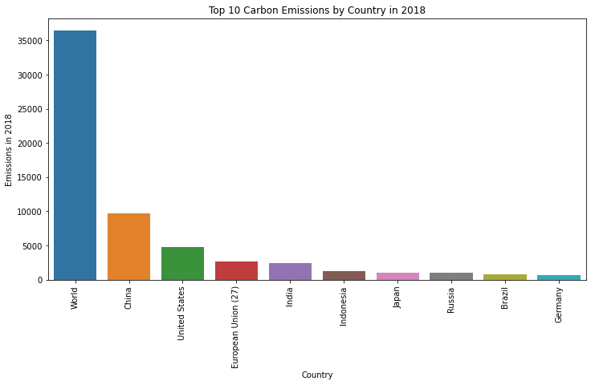

```python
# Calculate emissions by country
country_emissions = emissions1.groupby("Country")["2018"].sum().reset_index()

# Sort countries by emissions in descending order for the year 2018
top_N = 10
top_countries_2018 = country_emissions.nlargest(top_N, "2018")

# Visualization: Emissions by the top 10 countries in 2018
plt.figure(figsize=(12, 6))
sns.barplot(data=top_countries_2018, x="Country", y="2018")
plt.xticks(rotation=90)
plt.xlabel("Country")
plt.ylabel("Emissions in 2018")
plt.title("Top 10 Carbon Emissions by Country in 2018")
plt.show()
```

kindly ignore world!

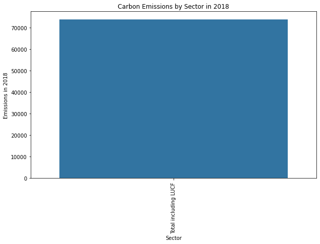

```python
# Visualization: Emissions by sector
plt.figure(figsize=(10, 6))
sns.barplot(x=sector_emissions.index, y=sector_emissions["2018"])
plt.xticks(rotation=90)
plt.xlabel("Sector")
plt.ylabel("Emissions in 2018")
plt.title("Carbon Emissions by Sector in 2018")
plt.show()
```

### Carbon Emission Forecast in the next 5 years

```python
from sklearn.linear_model import LinearRegression
```

```python
from statsmodels.tsa.holtwinters import ExponentialSmoothing
```

```python
import statsmodels.api as sm
```

```python
# Select the "World" row for the years 1990-2018
world_emissions = emissions1[emissions1["Country"] == "World"].iloc[:, 6:-1].values.flatten()
```

```python
# Create a time series object
time_series = pd.Series(world_emissions, index=pd.date_range(start="1990", periods=len(world_emissions), freq='Y'))
```

```python
# Define the forecasting period (next 5 years from 2018)
forecast_period = 5
forecast_dates = pd.date_range(start="2019", periods=forecast_period, freq='Y')
```

```python
from statsmodels.tsa.arima_model import ARIMA
```

```python
# Fit an ARIMA time series forecasting model
# You may need to adjust the model parameters based on your data
model = ARIMA(time_series, order=(0, 1, 1))  # Example order, adjust as needed
results = model.fit()
```

```python
# Forecast future emissions
forecast = results.forecast(steps=forecast_period)
```

```python
# Forecast future emissions
forecast, stderr, conf_int = results.forecast(steps=forecast_period)
```

[figure not shown]

```python
# Visualize the historical data and forecast
plt.figure(figsize=(12, 6))
plt.plot(time_series, label='Historical Data', marker='o')
plt.plot(forecast_dates, forecast, label='Forecast', linestyle='--', marker='o', color='orange')
plt.xlabel('Year')
plt.ylabel('Emissions')
plt.title('Carbon Emission Forecast for "World" (2019-2023)')
plt.legend()
plt.grid(True)
plt.show()
```

```python
# Print the forecasted values for the next 5 years
print("Forecasted Emissions for the next 5 years (2019-2023):")
print(forecast)
```

[output not shown]